# GoTo

Alexa-Skill für Suche von Öffi-Verbindungen und Mitfahrten

Martin Hochstrasser

27.06.2019

# Problem

Mitfahrten nicht einfach zu finden

Keine vereinte Suche mit öffentlichen Verkehrsmittel

# Lösungsansatz

[figure not shown]

Systemüberblick

## Erläuterung

- Alexa-Skill: Frontend für die Suche
- Angular-App: Frontend für das Eintragen der Fahrten
- ASP.NET Core: Backend für das Speichern der Fahrten und Suchen nach Öffi-Verbindungen

# GoTo.Service

**Zentrale** Schnittstelle für Angular und den Alexa Skill

Konfigurierbare Liste von Zielorten mit ihren Geo-Koordinaten

Speichert Mitfahrten und sucht nach Verbindungen mit öffentlichen Verkehrsmitteln

Abfrage von Orten über Name oder Geo-Koordinaten

## REST

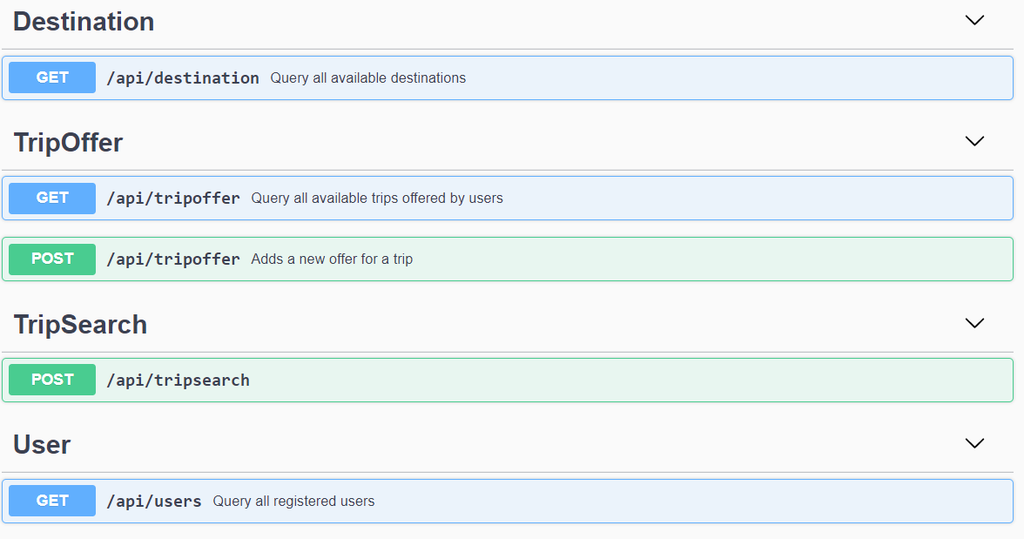

Swagger-UI der Schnittselle

## Suche nach Fahrten

Orte werden fuzzy gesucht. Es reicht dann aber eine exakte Suche.

Fahrten-Suche: zuerst bei den angeboteten Fahrten dann bei den öffentliche Verkehrsmitteln.

Google Maps - Einbindung war angedacht, es ist aber eine Kreditkarte (keine Prepaid) notwendig.

## Abfrage von Orten per Name

1. Entspricht der Ort einem bekannten Ort? (Groß-/Kleinschreibung irrelevant) -> wenn ja, Match
2. Ist er in einem bekannten Ort enthalten? -> wenn ja, Match
3. Berechnung der *Levenshtein*-Distanz für alle Orte
4. Sortieren nach Distanz und unter 2? -> wenn ja, Match
5. Liefere alle Orte sortiert nach der *Levenshtein*-Distanz

## Abfrage von Orten per Geo-Koordinaten

1. Berechne Distanz zwischen aktuellen Standort und bekannten Standorten
2. Alle Orten weiter als 100 km entfernt, werden aussortiert
3. Bester Match nach Distanz wird herangezogen

# GoTo.Lambda

**Schnittselle** für den Alexa-Skill

Kann auch über *Location Services* den aktuellen Standort bestimmen

Muss die Zeitzone des Benutzers abfragen, um richtige Anfragen stellen zu können

Bestes Ergebnis wird vorgelesen, die Anderen sind als *Card* sichtbar

Benützt [Alexa Skills SDK for .NET](https://github.com/timheuer/alexa-skills-dotnet)

## Intents

- TripSearchIntent
  - Slot `Source` (AMAZON.City)
  - Slot `Destination` (AMAZON.City)
- SpecifyLocationIntent
  - Slot `Location` (AMAZON.City)

## Fehlerbehandlung

Ziel oder Startort nicht erkannt: `SpecifyLocationIntent` mit dem fehlenden Ort

Für Ort, wird höchsten 3-mal nachgefragt. Bei Überschritten wird die Konversation zurückgesetzt (Eigener Counter als Session-Attribute).

# Demo

**Web-Oberfläche**

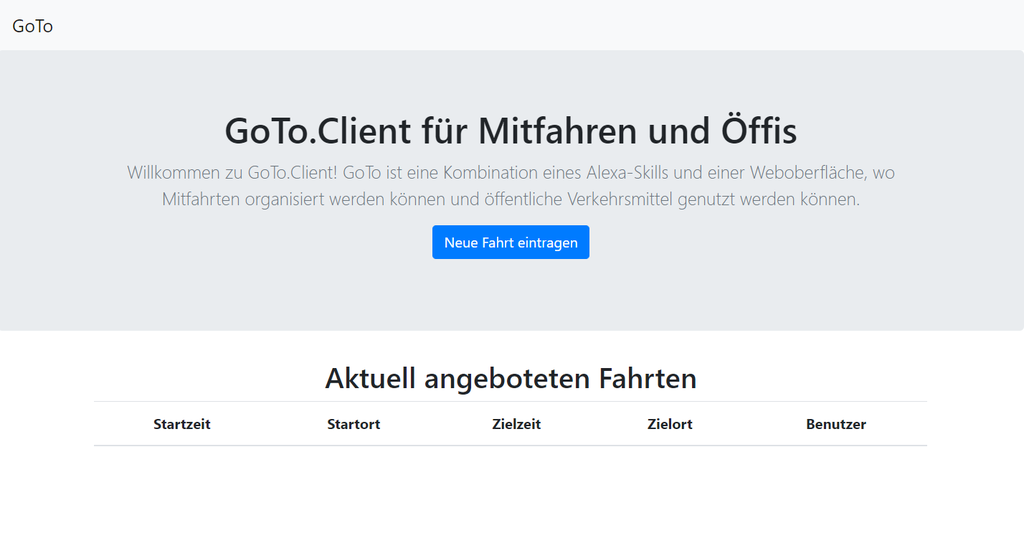

[GoTo](http://goto.eu-west-1.elasticbeanstalk.com/) aufrufen

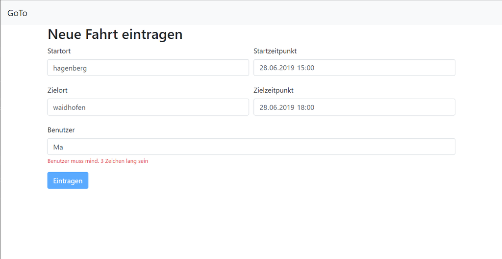

Fahrt anlegen

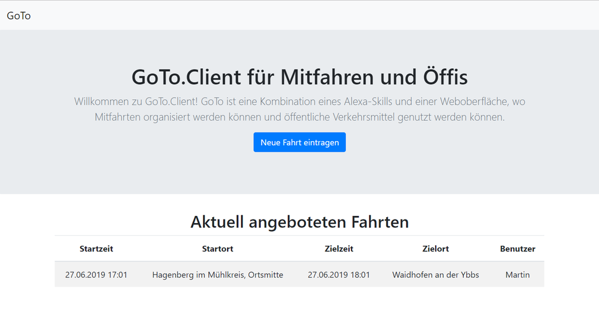

# Demo

**Alexa-Skill**

# Vielen Dank für eure Aufmerksamkeit!